# week06 - answer

[figure not shown]

```python
# X = X.reshape(216,384,3)
plt.imshow(X)
```

#### 练习1

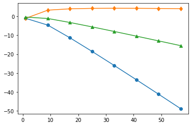

```python
x1_arr = np.arange(1, 64, 8)
y1_arr = 2 * np.log(x1_arr) - x1_arr
y1_arr2 = 2 * np.log2(x1_arr) - x1_arr**.5
y1_arr10 = 2 * np.log10(x1_arr) - x1_arr*(1/3)

plt.figure()
plt.plot(x1_arr,y1_arr, marker='o')
plt.plot(x1_arr,y1_arr2, marker='d')
plt.plot(x1_arr,y1_arr10, marker='^')
# plt.show()
```

#### 练习2

参考上周作业练习3

> 给出如下数组作为dataframe例子  
> 请编写一个函数，接受一个dataframe df和一个整数q，返回一个dataframe，其中数值大于(q-1)/q分位的数被改为1，小于等于n分位的被改为0

请编写一个**函数**接收三个参数df,q和x 从df(二值化后的DataFrame)抽取x(x <= 100)个例子并自2至q循环  
每次循环画出每一列数值大于(q-1)/q分位的数有几个  
要求给出图例

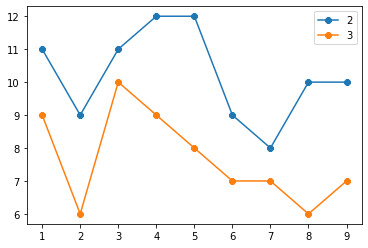

```python
data = np.random.randint(1,101,(100,9))
df0 = pd.DataFrame(data, columns=np.arange(9))

def bin_df(df, q):
    df2 = df.copy()
    row = df.shape[0]
    col = df.shape[1]
    ss = df0.quantile(q=(q-1)/q)
    for i in range(col):
        column_name = df.columns[i]
        df2[column_name] = df[column_name].apply(lambda x: 1 if x >= ss[i] else 0)
    return df2

def plotXrows(df, x, q=5):
    plt.figure()
    seed = np.random.randint(65535)
    for i in range(2, q+1):
        df2 = bin_df(df, i)
        df_toDraw = df2.sample(n=x, random_state=seed)
        y_arr = []
        for e in df_toDraw.columns:
            y_arr.append(np.sum(df_toDraw[e]==1))
        plt.plot(np.arange(1,10),y_arr, marker='8')
    plt.legend(labels=np.arange(2,q+1), loc='best')
plotXrows(df0, 20, 3)
```

**线性回归**  
[$f(x_i) = W^Tx\,+\,b~~~→~~~f(x)=w_1x_1+\dots+w_nx_n+b$](https://blog.csdn.net/liusanzhu/article/details/76375030)  
公式法:  
$\beta = (X^TX)^{-1}X^TY$  
逼近法:  
$\theta_0 = 2X^T(X\beta - Y)$  
$\theta_{k+1} = \theta_k - \alpha\cdot2X^T(X\beta - Y)$  
**多次幂线性回归**  
$y = \sum_{i=1}^mw_jx^j + b$

```python
class Linear:
    x_train = np.array([])
    y_train = np.array([])
    weight = np.array([])
    m = 0

    def __init__(self, x_train, y_train):
        self.m = x_train.shape[0]
        self.weight = np.zeros(x_train.shape[1])
        self.weight = np.append(self.weight, 0)
        self.x_train = np.append(x_train, np.ones((x_train.shape[0],1)), axis=1)
        self.y_train = y_train


    def mae(self, y_test, y_pred):
        return np.sum(np.abs(y_test-y_pred)) / self.m

    def mse(self, y_test, y_pred):
#         return np.sum((y_test-y_pred)**2) / self.m
        return np.sum((y_test-y_pred)**2) / self.m

    def rmse(self, y_test, y_pred):
        return self.mse(y_test, y_pred) ** 0.5

    def loss(self, x_test, y_test, func):
        y_pred = self.predict(x_test)
        return func(y_test, y_pred)

    def fit(self, lr=0.01, num_iter=20):
        x = self.x_train
        y = self.y_train
        w = np.array(2 * np.dot(x.T, (np.dot(x,self.weight) - y).T)).flatten()
        loss_min = np.PINF
        w_min = w
        for epoch in range(num_iter):
            w -= np.array(lr * 2 * np.dot(x.T, (np.dot(x,w) - y).T)).flatten()
            loss = self.loss(self.x_train[:,:-1], self.y_train, func=self.rmse)
            if epoch % 20000 == 0:
                print(f"iteration:{epoch}, loss:{loss}")
            if epoch >= 20000 and loss > loss_min:
                print(f"local optimum at iteration:{epoch}, loss:{loss}")
                break
            elif loss < loss_min:
                loss_min = loss
                w_min = w
        self.weight = w_min

    def fit2(self):
        x = self.x_train
        y = self.y_train
        a = np.dot(x.T, x)
        try:
            a = a.I
            b = np.dot(a, x.T)
            w = np.dot(b, y)
            self.weight = w
        except:
            print(f'矩阵\n{a}\n没有逆矩阵')

    def predict(self, x_test):
        w = self.weight[:-1]
        b = self.weight[-1]
        y_pred = np.array(np.dot(x_test, w) + b).flatten()
        return y_pred

    def toString(self):
        s = 'y = '
        for i in range(self.weight.shape[0]):
            s += str(self.weight[i])+'x'+str(i+1)+' + ' if i < self.weight.shape[0]-1 else str(self.weight[i])
        return s

class PowerLinear(Linear):
    x_train = np.array([])
    y_train = np.array([])
    weight = np.array([])
    m = 0
    n = 0

    def __init__(self, xarr, yarr, n=3):
        self.n = n
        x = xarr.reshape(xarr.shape[0], -1)
        x_tmp = x[:]
        for i in range(2, n+1):
            x = np.append(x, x_tmp ** i, axis=1)
        Linear.__init__(self, np.mat(x), yarr)

    def powerPredict(self, xarr, n=3):
        x = xarr.reshape(xarr.shape[0], -1)
        x_tmp = x[:]
        for i in range(2, n+1):
            x = np.append(x, x_tmp ** i, axis=1)
        return self.predict(np.mat(x))

    def powerLoss(self, x_test, y_test, func):
        y_pred = self.powerPredict(x_test, n=self.n)
        return func(y_test, y_pred)


    def toString(self):
        s = 'y ='
        for i in range(self.weight.shape[0]):
            s += str(self.weight[i])+'x + ' if not i else str(self.weight[i])+'x^'+str(i+1)+' + ' if i < self.weight.shape[0]-1 else str(self.weight[i])
        return s

x_train = np.array([6,5,4,3,2])
y_train = x_train ** 2 - x_train + 20
pl_model = PowerLinear(x_train, y_train, 2)
# print(pl_model.x_train)
pl_model.fit(lr=0.0001, num_iter=50000)
print(f'逼近法公式:\n{pl_model.toString()}')
print(f'逼近法预测:\n{pl_model.powerPredict(x_train, n=2)}')
```

```
iteration:0, loss:35.45137514963277
iteration:20000, loss:35.45137514963277
iteration:40000, loss:35.45137514963277
逼近法公式:
y =4.755120947554434x + 0.31042845869102376x^2 + 9.28665141065538
逼近法预测:
[48.99280161 40.82296762 33.27399054 26.34587038 20.03860714]
```

#### 练习3

参考上周的多次幂线性回归  
自己创建数据设计函数**(3次幂及以上)**及调参以训练模型  
训练后将模型预测结果及实际结果画在同一张图上并显示图例  
注意: 对n次幂公式拟合时建议使用同样的幂数  
建议x范围在$[1.0, 3.0]$区间以避免多次幂过小或过大  
应适当调整参数使预测结果接近实际结果

```
iteration:0, loss:13.983044592363093
iteration:20000, loss:13.983044592363093
iteration:40000, loss:13.983044592363093
```

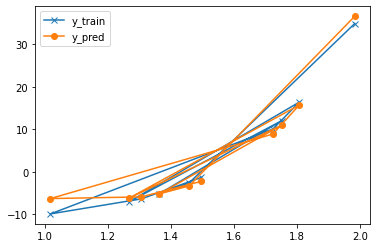

```python
x_train = np.random.rand(10) + 1
y_train = 3 * x_train ** 5 - 5 * x_train ** 4 + 7 * x_train ** 3 - 11 * x_train ** 2 + 13 * x_train ** 1 - 17
pl_model = PowerLinear(x_train, y_train, 5)
pl_model.fit(lr=0.00001, num_iter=50000)
# print(f'逼近法公式:\n{pl_model.toString()}')
# print(f'逼近法预测:\n{pl_model.powerPredict(x_train, n=5)}')
y_pred = pl_model.powerPredict(x_train, n=5)

plt.figure()
plt.plot(x_train, y_train, marker='x')
plt.plot(x_train, y_pred, marker='o')

plt.legend(labels=['y_train', 'y_pred'], loc='best')
```

#### 练习4

参考上周作业练习2

> 使用numpy生成随机数组，以添加'身高(cm)'列，范围${\;}[140, 200]{\;}$; 和'体重(kg)'列，范围${\;}[30, 100]{\;}$  
> 添加BMI列，根据生成的身高体重列计算BMI$bmi = \frac{体重(kg)}{身高(m)^2}$

绘制一张图片并分别画出男性和女性的BMI同时给出图例  
男女各标注一名例子，在标注中写出姓名和BMI  
根据图表美观有一定的分

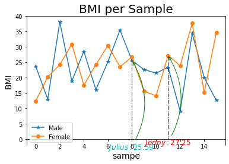

```python
data = [['Alex', 'M', 16], ['Alpha', 'M', 17], ['Allen', 'M', 18], ['Athena', 'F', 19],
        ['Chad', 'M', 17], ['Chole', 'F', 18], ['Dane', 'F', 19], ['Dale', 'F', 20],
        ['Frances', 'M', 18], ['Olivia', 'F', 19], ['Dave', 'M', 20], ['David', 'M', 21],
        ['John', 'M', 19], ['Ada', 'F', 20], ['Jane', 'F', 21], ['Ivy', 'F', 22],
        ['Julius', 'M', 20], ['Amy', 'F', 21], ['Irene', 'F', 22], ['Irma', 'F', 23],
        ['Jim', 'M', 21], ['Joseph', 'M', 22], ['Jenny', 'F', 23], ['Jennifer', 'F', 24],
        ['Micheal', 'M', 22], ['Crystal', 'F', 23], ['Claire', 'F', 24], ['Christine', 'F', 25],
        ['Kent', 'M', 23], ['Kenneth', 'M', 24], ['Justin', 'M', 25], ['Joyce', 'M', 26]]
df1 = pd.DataFrame(data, columns=['name', 'gender', 'age'])
def calBmi(df):
    df2 = df.copy()
    n = df2.shape[0]
    df2['height'] = np.random.randint(140,201,n)
    df2['weight'] = np.random.randint(30,101,n)
    df2['BMI'] = np.round(df2['weight']/df2['height']/df2['height']*10000,2)
    return df2
df1 = calBmi(df1)
df_m = df1[df1.gender == 'M'].reset_index()
df_f = df1[df1.gender == 'F'].reset_index()

plt.figure()
plt.title('BMI per Sample', fontsize=20)
plt.xlabel('sampe', fontsize=14)
plt.ylabel('BMI', fontsize=14)
plt.plot(np.array(df_m['BMI']), marker='*')
plt.plot(np.array(df_f['BMI']), marker='o')
plt.legend(labels=['Male', 'Female'], loc='best')

ax = plt.gca()
ax.spines['bottom'].set_position(('data', 0))
nM = np.random.randint(16)
nameM = df_m['name'][nM]
bmiM = df_m['BMI'][nM]

nF = np.random.randint(16)
nameF = df_f['name'][nF]
bmiF = df_f['BMI'][nF]


plt.plot([nM, nM], [bmiM, 0], color='k', linestyle='-.', linewidth=1.0)
plt.annotate(r"$%s: %.2f$"%(nameM,bmiM), color='c',
             xy=(nM, bmiM), xycoords='data',xytext=(-40, -150), textcoords='offset points',fontsize=12,
             arrowprops=dict(color='green', arrowstyle='->',connectionstyle='arc3, rad=0.3'))

plt.plot([nF, nF], [bmiF, 0], color='k', linestyle='-.', linewidth=1.0)
plt.annotate(r"$%s: %.2f$"%(nameF,bmiF), color='r',
             xy=(nF, bmiF), xycoords='data',xytext=(-40, -150), textcoords='offset points',fontsize=12,
             arrowprops=dict(color='green', arrowstyle='->',connectionstyle='arc3, rad=0.3'))
plt.show()
```